# L3_ Segmentation Methods

Nicole Barbour

2024-05-17

# Load Data In

First, let’s load in our processed data from lab 1.

```r
load("./data/elk_processed.rda")

head(elk_gps)
```

```
##              datetime       lon      lat   id
## 1 2001-12-13 07:01:00 -115.8043 52.12410 4049
## 2 2001-12-13 09:01:00 -115.8003 52.11762 4049
## 3 2001-12-14 09:01:00 -115.8281 52.09611 4049
## 4 2001-12-14 11:00:00 -115.8318 52.09829 4049
## 5 2001-12-14 17:02:00 -115.8042 52.09482 4049
## 6 2001-12-14 19:01:00 -115.8037 52.12493 4049
```

# Select Example Individual and Visualize

We will use one individual from our data as an example, “YL96”. This individual has some “patches” of residency-like behavior along its track.

```r
elk_example_data <- subset(elk_gps, id == "YL96") |>
  dplyr::mutate(id = as.character(id))

str(elk_example_data)
```

```
## 'data.frame':    4129 obs. of  4 variables:
##  $ datetime: POSIXct, format: "2004-03-29 17:00:00" "2004-03-29 19:02:00" ...
##  $ lon     : num  -116 -116 -116 -116 -116 ...
##  $ lat     : num  51.7 51.8 51.7 51.7 51.7 ...
##  $ id      : chr  "YL96" "YL96" "YL96" "YL96" ...
```

We can use Base R to visualize the track of this individual in space and time, using the methods we learned in lab 1:

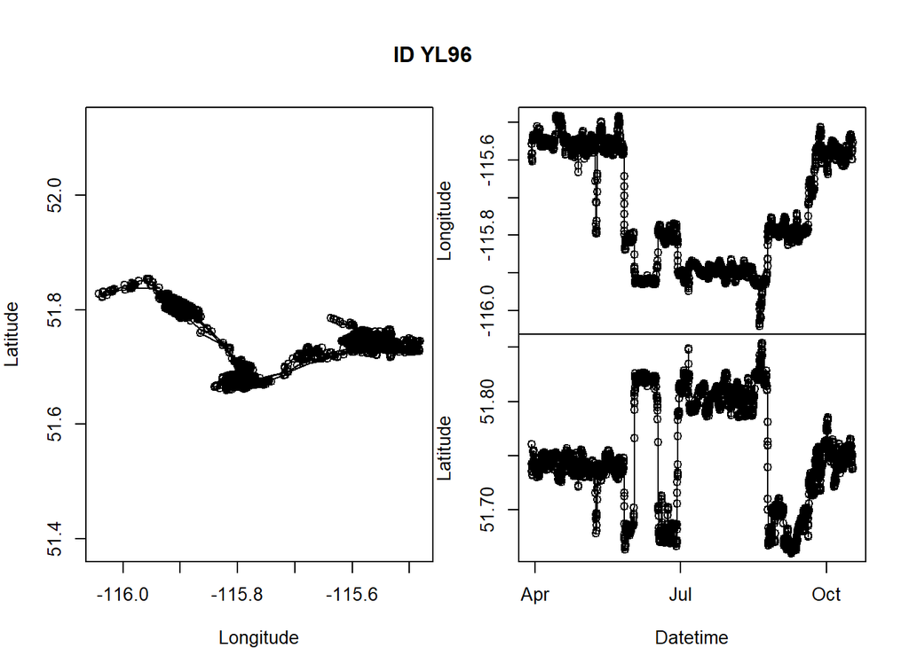

```r
par(mar = c(0,4,0,0), oma = c(4,0,5,2), xpd=NA)
layout(rbind(c(1,2), c(1,3)))
plot(elk_example_data$lon, elk_example_data$lat, asp = 1, type="o", ylab="Latitude", xlab="Longitude")
plot(elk_example_data$datetime, elk_example_data$lon, type="o", xaxt="n", ylab="Longitude", xlab="")
plot(elk_example_data$datetime, elk_example_data$lat, type="o", ylab="Latitude", xlab="Datetime")
title(paste("ID", elk_example_data$id[1]), outer = TRUE)
```

# First Passage Time

First Passage Time (FPT) can be a useful parameter to describe scales of behavior along a movement track.

It is generally defined as the time observed for an animal to pass through a circle, with radius “r”, where “r” defines the scale of behavior.

The variance of the log of the FPT can be used to select this scale, “r”, with a high variance (peak) being seen for scales often used by more residential-like behavior (e.g., slower, more tortuous movements).

## Transform Data into “ltraj” Format

First Passage Time is calculated using the “adehabitatLT” package. We will also need the “sf” package.

```r
library(adehabitatLT)
library(sf)
```

In order to fit the `fpt` function, we first need to:

1 - make our data spatial (sf)

2 - convert our data to be “SpatialPoints” format (from another spatial package, sp, which is automatically installed and loaded with the adehabitatLT package).

```r
elk_example_sp <- elk_example_data |>
  st_as_sf(coords=c("lon","lat"), crs= 4326) |>
  st_transform(32611) |>
  st_cast("POINT") |>
  as_Spatial()

str(elk_example_sp)
```

```
## Formal class 'SpatialPointsDataFrame' [package "sp"] with 5 slots
##   ..@ data       :'data.frame':  4129 obs. of  2 variables:
##   .. ..$ datetime: POSIXct[1:4129], format: "2004-03-29 17:00:00" "2004-03-29 19:02:00" ...
##   .. ..$ id      : chr [1:4129] "YL96" "YL96" "YL96" "YL96" ...
##   ..@ coords.nrs : num(0)
##   ..@ coords     : num [1:4129, 1:2] 599661 597701 597142 596939 596472 ...
##   .. ..- attr(*, "dimnames")=List of 2
##   .. .. ..$ : NULL
##   .. .. ..$ : chr [1:2] "coords.x1" "coords.x2"
##   ..@ bbox       : num [1:2, 1:2] 566015 5723850 604798 5745330
##   .. ..- attr(*, "dimnames")=List of 2
##   .. .. ..$ : chr [1:2] "coords.x1" "coords.x2"
##   .. .. ..$ : chr [1:2] "min" "max"
##   ..@ proj4string:Formal class 'CRS' [package "sp"] with 1 slot
##   .. .. ..@ projargs: chr "+proj=utm +zone=11 +datum=WGS84 +units=m +no_defs"
##   .. .. ..$ comment: chr "PROJCRS[\"WGS 84 / UTM zone 11N\",\n    BASEGEOGCRS[\"WGS 84\",\n        ENSEMBLE[\"World Geodetic System 1984 "| __truncated__
```

We can now use the `as.ltraj` function to convert out data into ltraj format.

```r
elk_example_traj <- as.ltraj(coordinates(elk_example_sp), date = elk_example_data$datetime, id = elk_example_data$id)

summary(elk_example_traj)
```

```
##     id burst nb.reloc NAs          date.begin            date.end
## 1 YL96  YL96     4129   0 2004-03-29 17:00:00 2004-10-17 09:00:00
```

We can use the `head` function to look at the ltraj data table for this individual.

```r
head(elk_example_traj[[1]])
```

```
##          x       y                date         dx          dy      dist   dt
## 1 599661.1 5733368 2004-03-29 17:00:00 -1960.2917  2004.18194 2803.4780 7320
## 2 597700.8 5735372 2004-03-29 19:02:00  -558.4716 -2829.92571 2884.5052 7140
## 3 597142.4 5732542 2004-03-29 21:01:00  -203.6384   -42.86034  208.1000 7200
## 4 596938.7 5732500 2004-03-29 23:01:00  -466.3606  -391.65474  609.0038 7140
## 5 596472.4 5732108 2004-03-30 01:00:00   244.5432   108.15146  267.3914 7260
## 6 596716.9 5732216 2004-03-30 03:01:00  1171.0849   346.35853 1221.2306 7140
##        R2n  abs.angle  rel.angle
## 1        0  2.3451241         NA
## 2  7859489 -1.7656377  2.1724236
## 3  7026021 -2.9341477 -1.1685101
## 4  8165944 -2.4430437  0.4911040
## 5 11756458  0.4163979  2.8594416
## 6  9995777  0.2875611 -0.1288368
```

We can also plot the trajectory of the individual, which shows the start and end locations in red and blue.

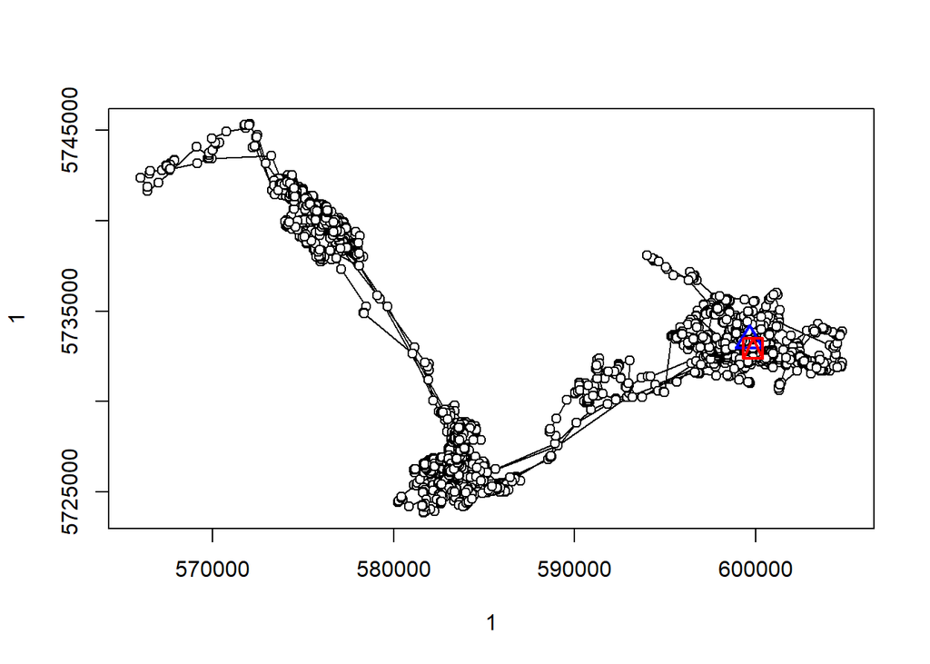

```r
plot(elk_example_traj)
```

```r
elk_example_fpt <- fpt(elk_example_traj, radii = seq(1000, 10000, by = 1000), units="hours")
```

Next, we can use the `varlogfpt` function on our FPT object to see if we can find a peak in the variance at one of the spatial scales of interest.

We can see a plateau in the variance at ~4000-5000 m.

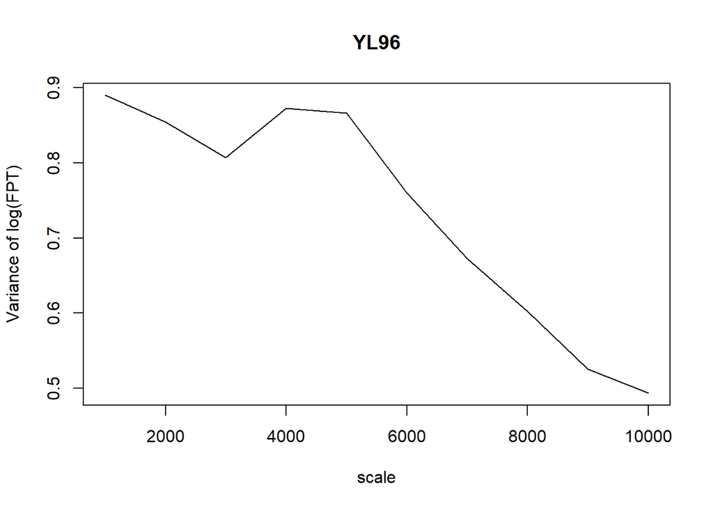

```r
varlogfpt(elk_example_fpt, graph=TRUE)
```

Now that we have decided on our spatial scale of interest, we can refit our `fpt` function and plot the results.

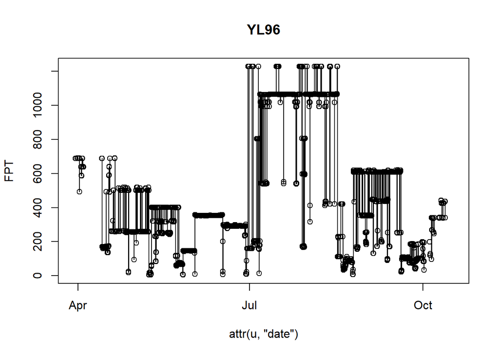

```r
elk_example_fpt <- fpt(elk_example_traj, radii = 5000, units="hours")

plot(elk_example_fpt, scale = 5000, warn = FALSE)
```

We can bind our FPT values to our data as a column by extracting it from our FPT object.

We can plot these values over our latitude values by scaling both of them (`scale` function).

Periods of higher FPT seem to mostly correspond to the distinct patches of possible “residential” behavior.

```r
library(ggplot2)
```

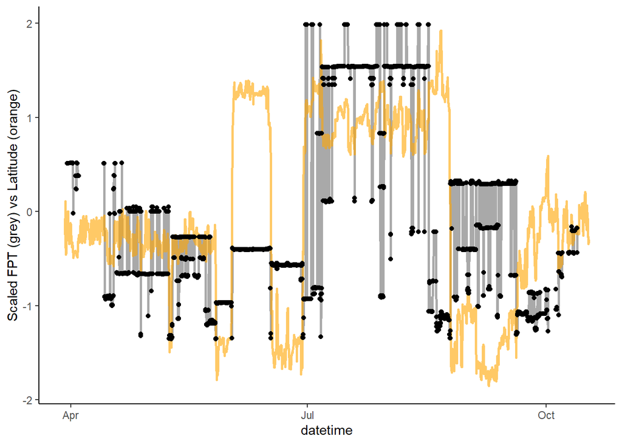

```r
elk_example_data$FPT <- elk_example_fpt[[1]]$r1

ggplot() +
  geom_path(data = elk_example_data, aes(x = datetime, y = scale(FPT)), color="darkgrey", size = 1) +
  geom_path(data = elk_example_data, aes(x = datetime, y = scale(lat)), color ="orange", alpha = 0.6, size = 1) +
  geom_point(data = elk_example_data, aes(x = datetime, y = scale(FPT))) +
  theme_classic() +
  ylab("Scaled FPT (grey) vs Latitude (orange)")
```

# Lavielle Method

Lavielle’s method identifies behavioral break points by applying a moving window over the timeseries. The optimal number of segments, k, in the timeseries is then determined by minimizing the “penalized contrast function” (Lavielle 2005). Break points are determined using the mean, variance, or mean AND variance along the timeseries of the variable of interest (e.g., speed).

We will use the same example dataset as in the FPT analysis, to compare results.

```r
str(elk_example_data)
```

```
## 'data.frame':    4129 obs. of  5 variables:
##  $ datetime: POSIXct, format: "2004-03-29 17:00:00" "2004-03-29 19:02:00" ...
##  $ lon     : num  -116 -116 -116 -116 -116 ...
##  $ lat     : num  51.7 51.8 51.7 51.7 51.7 ...
##  $ id      : chr  "YL96" "YL96" "YL96" "YL96" ...
##  $ FPT     : num  NA NA NA NA NA NA NA NA NA NA ...
```

This method also uses the “adehabitatLT” package.

The Lavielle Method is fit using the `laveielle` function, where the user can specify the:

1 - variable from the dataset to distinguish the segments by (here, we will use latitude)

2 - Lmin - the minimum number of relocations within a segment

3 - Kmax - the maximum number of segments to “try out”

4 - type - how to distinguish the segments (mean, variance, or both, “meanvar”)

We can use the visualizations of our track to inform our decisions on these parameters.

Here, we will use a minimum of 20 locations, max of 5 segments, and the mean to determine segments by latitude.

```r
elk_lavielle_example <- lavielle(elk_example_data$lat, Lmin = 20, Kmax = 5, type = "mean")
```

After fitting, we can use the `chooseseg` function to identify the number of segments.

Here it looks the the optimal number, k, is 3.

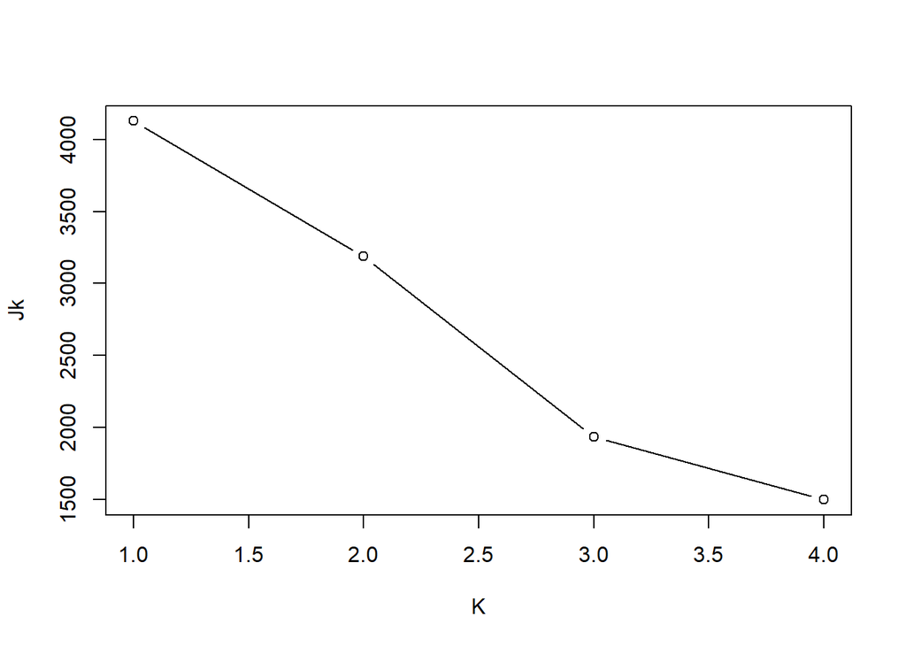

```
##   K          D       Jk
## 1 1        Inf 4128.000
## 2 2 -0.3730165 3187.259
## 3 3  0.9770469 1934.889
## 4 4 -0.3307970 1498.771
```

```r
chooseseg(elk_lavielle_example)
```

We can now create a nice plot of these segments, with the change in latitude over time and the red lines dilineating the break points for each segment.

```r
elk_lavielle_example_path <- findpath(elk_lavielle_example, 3)
```

[figure not shown]

If we wanted to bind these predictions back to our data, we can do so in a series of steps, first extracting the breakpoints as a vector from our previous object, then adding them to the original data using the `merge` function and the “tidyr” package’s, `fill` function to fill in values with their corresponding segment.

```r
breakpoints <- unlist(elk_lavielle_example_path)

breakpoints
```

```
## [1]    1 1629 1630 2947 2948 4129
```

```r
breakpoints_df <- data.frame(Row_ID = breakpoints, segment = c(1,1,2,2,3,3))

elk_example_data$Row_ID <- cumsum(rep(1, nrow(elk_example_data)))

elk_example_data_lav <- merge(elk_example_data, breakpoints_df, by="Row_ID", all.x=TRUE)

elk_example_data_lav <- tidyr::fill(elk_example_data_lav, segment, .direction = 'down')

head(elk_example_data_lav)
```

```
##   Row_ID            datetime       lon      lat   id FPT segment
## 1      1 2004-03-29 17:00:00 -115.5565 51.74235 YL96  NA       1
## 2      2 2004-03-29 19:02:00 -115.5843 51.76071 YL96  NA       1
## 3      3 2004-03-29 21:01:00 -115.5932 51.73537 YL96  NA       1
## 4      4 2004-03-29 23:01:00 -115.5962 51.73502 YL96  NA       1
## 5      5 2004-03-30 01:00:00 -115.6030 51.73158 YL96  NA       1
## 6      6 2004-03-30 03:01:00 -115.5995 51.73251 YL96  NA       1
```

We can visualize the final results using ggplot:

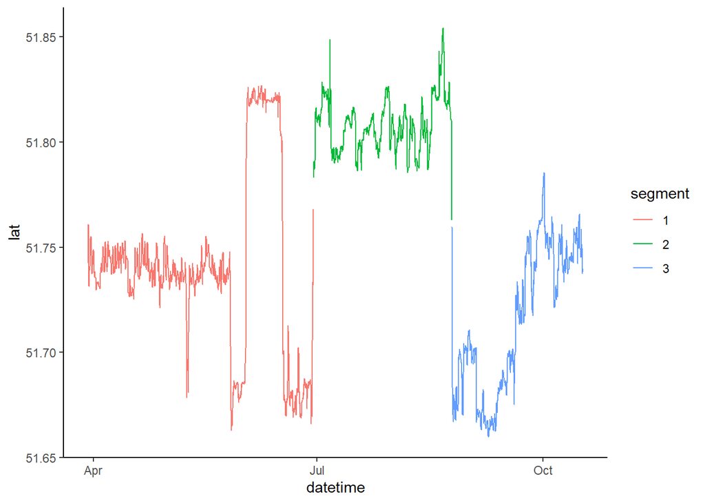

```r
elk_example_data_lav$segment <- as.character(elk_example_data_lav$segment)

ggplot(data=elk_example_data_lav, aes(x=datetime, y=lat, color = segment)) +
  geom_path()+
  theme_classic()
```